# Statistical observation and organization of the data

## Statistics as a science

**Statistics** is a social science that studies **mass phenomena and processes** occurring in society, as well as economic and social conditions of society. All phenomena and processes studied by statistics in specific conditions of place and time, in continuous development and interrelation with each other.

**Objects of statistical research** are mass economic and social phenomena and processes occurring in society. **The subject matter of statistics** are **dimensions and levels of the studied phenomena and processes**.

## Objectives of statistics

**Statistics creates and analyzes quantitative and qualitative characteristics of studied phenomena and processes** in their continuous development and interrelation with each other. **The global objective of statistics is to prepare and present complete and reliable information on the state and development of the economy of the country**. More specific tasks are:

1. Implementation of international accounting and statistical rules in practice.
2. Improvement of statistical information in the conditions of market economy.
3. Strengthening of reporting discipline.

## Federal State Statistics Service.

The supreme body of the Federal State Statistics Service of the Russian Federation is **Rosstat**.

The scope of activity of the statistical service is defined in the Regulation on the Federal Service of State Statistics, which is approved by the Resolution of the Government of the Russian Federation No. 420 of June 2, 2008. According to this Regulation, Rosstat is an authorized federal executive body performing the functions:

- to develop drafts of normative legal acts in the sphere of state statistical activity;
- formation of **official statistical information on the social, economic, demographic and environmental situation of the country**;
- control in the sphere of state statistical activity in the order and cases established by the legislation of the Russian Federation.

Structural subdivisions of the central apparatus of Rosstat are departments for the main directions of its activity. Rosstat carries out its work directly through its territorial bodies in cooperation with other federal executive authorities, executive authorities of the subjects of the Russian Federation, local governments, public associations and other organizations.

It manages statistical reporting and accountability in all sectors of the economy and bears full responsibility for the creation and functioning of **statistical information system at the national, sectoral and regional levels**.

## Elements of statistics

**The original concept of statistics is the concept of statistical population**, which is understood as a mass phenomenon that is being studied at a given moment by statistics (e.g. population of a country). Each statistical population consists of separate elements, which are called **units of statistical population** (for population - person, family, population of some region, nationality, etc.).

Each unit of the population has certain properties. **A characteristic in statistics is a property or quality of a population unit** that can be defined or measured (for a person - sex, height, age, weight, etc.). Signs are divided into **quantitative** and **qualitative** (attributive).

Each unit of the population has a certain value of a trait (feature). The change in the value of a trait from one unit of the population to another in statistics is called **variation of a trait**. By nature, variations of a feature are divided into multiple (taking different values) and alternative (taking only 2 values).

## Stages of statistical research

In any statistical study, 3 stages are distinguished:

1. statistical observation
2. summary and grouping
3. calculation of summary indicators and analysis of the obtained data.

## Statistical observation

Statistical observation is a systematized and scientifically justified collection of primary statistical data on the phenomenon under study by recording individual values of the trait of individual units of the population. The main task of statistical observation is to obtain in the shortest possible time complete and reliable information about the phenomenon under study.

In practice 2 organizational forms of statistical observation are applied:

1. **Statistical reporting**, in which legal and natural persons according to the established form in due time provide the necessary information to the statistical authorities.
2. Specially organized **observation**, which is conducted either for verification of statistical reporting data or for obtaining data for which statistical reporting is not provided (example: population census).

The following types of statistical observation are distinguished:

1. According to the coverage of population units - **continuous** and **non-consolidated**. In its turn, non-consolidated is subdivided into sampling, main mass and monographic.
2. According to the basis for registration of a feature - **direct**, **documentary** and **survey.**
3. By the nature of registration of the sign in time - **discontinuous** and **continuous.**

For the correct organization of statistical observation approve the program, which establishes the goals and objectives of observation, defines the object and unit of observation, chooses the type and method of observation, place and time of its conduct, establishes the circle of persons responsible for conducting the observation and the terms of providing the necessary information.

## Statistical Summary (organization of the data)

Summary is the second stage of statistical research and consists in the fact that primary data obtained during statistical observation are systematized and summarized. According to the technique of execution, the summary is manual and mechanized. At the stage of summary is used grouping - a method in which the entire original population is divided into groups by some essential feature. The characteristic underlying the grouping is called the grouping characteristic.

A distinction is made between **simple** and **complex** summarization:

- In **simple** summarization, only the totals of the entire population as a whole are calculated.
- In a **complex** summary, the initial population is divided into groups, the totals in each group and the population as a whole are calculated, and the obtained data are presented in the form of statistical tables.

If the units of the initial population are grouped only by the first characteristic, it is called **simple**, if by the second and more characteristics - **combinational.**

The most important issue of grouping is to determine the number of groups to be allocated. If the grouping is based on a qualitative (attributive) attribute, the number of groups to be allocated is determined by this attribute itself. If the grouping is based on a quantitative attribute, special calculations are made to determine the number of selected groups and the size of grouping intervals.

## Grouping

**A grouping interval** is the value of a varying characteristic lying within certain limits (for example: the size of wages from 5 to 12 thousand rubles). The minimum value of the interval is called its **lower boundary** , the maximum value is called its **upper boundary**.

The value of the interval is denoted **i** and is defined as the difference between the upper and lower boundaries in each interval. Grouping intervals are open and closed, equal and unequal.

**A closed** interval is one that has both lower and upper boundaries. If one of the boundaries is missing, the interval is considered **open**. When solving problems, an open grouping interval is closed by the value of the adjacent interval.

If each of the selected groups has the same interval value, then such intervals are considered **equal**, otherwise they are considered **unequal**.

The number of groups with unequal intervals depends on the available background information and the objectives of the study. If the variation of a characteristic is manifested within relatively narrow boundaries, then grouping of population units with equal intervals is performed.

## Equal interval grouping

The number of equal interval groups to be allocated is determined by the Sturgess formula:

$$n = 1+3,322 \times lg (N)$$

N - number of units of the initial population,

n - number of groups with equal intervals.

- For **N** from 15 to 24: **n** = 5;
- At **N** from 25 to 44: **n** = 6;
- At **N** from 45 to 89: **n** = 7.

The value of the equal interval is determined by the formula:

$$i = \frac{x_{max} - x_{min} }{n}$$

where $x_{max}$ and $x_{min}$ correspond to the maximum and minimum values of the trait in the initial population, and $n$ is the number of selected groups with equal intervals.

## Grouping with equal intervals

After determining the grouping characteristic, the number of groups to be selected and the size of the grouping intervals, the data are presented in the form of distribution series.

**A statistical distribution series** is an ordered distribution of units of the original population into groups according to some essential characteristic. Depending on the grouping characteristic, attributive and variation distribution series are distinguished.

Schematically, variation distribution series are represented in the form of two columns. The first column contains individual values of the trait, they are called **variates** and are denoted by **X**.

The second column contains:

1. Absolute numbers showing how many times a given value of the trait (a given variant) occurs in the original population. Such absolute numbers are called **frequencies** and are denoted by a letter. The sum of all frequencies must be equal to the total number of units of the original population.
2. Relative numbers showing the share (specific weight) of each group in the total number of units of the original population. Such relative numbers are called **frequencies** and are denoted by **W**. The sum of all frequencies must be equal to 1 or 100%. Schematic diagram of the variation series of the distribution:

| **X** | **ƒ(W)** |
| --- | --- |
| **.** | **.** |
| **.** | **.** |
| **.** | **.** |
| **Total** | **.** |

Depending on the nature of variation of a characteristic, discrete and interval variation series of distribution are distinguished. If the values of a characteristic (variations) are represented as integers, such **variation series is called discrete** (for example: the distribution of 20 families by the number of children in them is given).

| **Number of children** | **Number of families** |
| --- | --- |
| **Х** | **ƒ** |
| **0** | **3** |
| **1** | **8** |
| **2** | **4** |
| **3** | **3** |
| **4** | **2** |
| **Total** | **20** |

Discrete variation series are depicted as a **polygon** of distribution. To construct it, individual values of the trait (variants) are plotted along the abscissa axis, and frequencies (frequencies) along the ordinate axis.

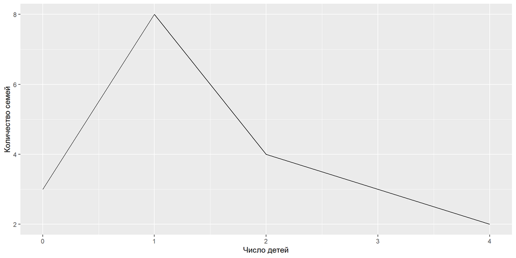

If the values of a characteristic (variants) are presented in the form of intervals, such **variation series is called interval** (for example: the distribution of 30 employees of the firm by the size of monthly salary (thousand rubles) is given). Interval variation series are represented graphically in the form of a **histogram**.

| Salary (thousand rubles per month), **X** | Number of employees (number of people), **ƒ** | **S** |
| --- | --- | --- |
| 5-10 | 3 | 3 |
| 10-15 | 12 | 15 |
| 15-18 | 10 | 25 |
| 18-25 | 5 | 30 |
| **Total** | **30** | - |

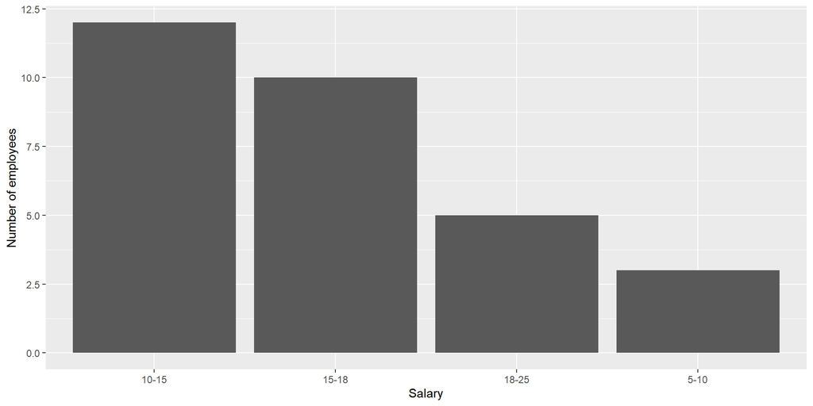

To construct it, segments whose length corresponds to the grouping intervals are laid off along the abscissa axis. These segments are the lower bases of the rectangles formed, and the corresponding frequency or frequency rate is the height of these rectangles, respectively. In some cases, an interval variation series is represented graphically in the form of **cumulata**.

For its construction, it is necessary to accumulate frequencies (frequencies). They are denoted **S** and are determined by successive summation of frequencies (frequencies) preceding the interval.

The cumulative frequency shows how many units of the initial population have a value of a feature (variant) not more than the one under consideration (for example: the cumulative frequency equals 25, which means that 25 employees out of 30 have a salary of no more than 18 thousand rubles per month).

When building the cumulata, the entire accumulated frequency (frequency) of the interval is assigned to the upper boundary of the interval. To build the cumulata, the upper boundaries of intervals are plotted on the abscissa axis, and the accumulated frequencies (frequencies) are plotted on the ordinate axis.

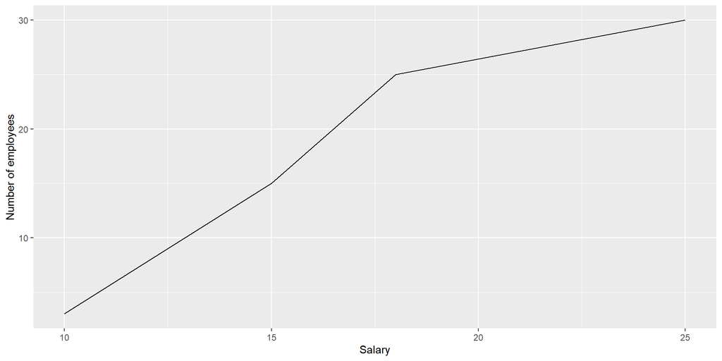

In practice, it is sometimes necessary to use existing groupings that may not be comparable for the following reasons:

1. Unequal boundaries of the grouping intervals.
2. Different number of groups to be selected.

To make such groupings comparable, the **method of secondary grouping** is used. There are 2 methods of secondary grouping:

1. **Method of enlargement of grouping intervals**.
2. **Method of share regrouping** , which consists in assigning to each group a certain share of units of the original population.

The **classifications** should be distinguished from groupings. The peculiarities of classifications are that they are based on qualitative attributes. They are established by state and international statistical agencies and remain unchanged for a long period of time.